# XGBoost - Income Classification

Piotr Wieczorek

2023-10-14

```r
rm(list=ls())
```

## Goal of this project

### The goal of this project is to use XGBoosting algorithm to predict the income group (either >50K or <=50K) based on the following variables:

#### age

#### work class

#### education

#### marital status

#### occupation

#### race

#### sex

#### hours per week (of work)

#### native country

## Libraries and reading the data

```r
library(tidyverse)
library(caret)
library(fastDummies)
library(performance)
library(psych)
library(gridExtra)
library(rcompanion)
library(kableExtra)
library(xgboost)
library(png)
library(ggpubr)
library(glue)
library(missForest)
```

```r
rm(list = ls())
```

```r
df <- read_csv("C:/Users/piotr/Desktop/R_files/adult.csv")
```

## Exploring the data set

```r
colnames(df)
```

```
##  [1] "age"            "workclass"      "fnlwgt"         "education"
##  [5] "education.num"  "marital.status" "occupation"     "relationship"
##  [9] "race"           "sex"            "capital.gain"   "capital.loss"
## [13] "hours.per.week" "native.country" "income"
```

### Replacing “?” signs with NaN values

```r
str(df)
```

```
## spc_tbl_ [32,561 × 15] (S3: spec_tbl_df/tbl_df/tbl/data.frame)
##  $ age           : num [1:32561] 90 82 66 54 41 34 38 74 68 41 ...
##  $ workclass     : chr [1:32561] "?" "Private" "?" "Private" ...
##  $ fnlwgt        : num [1:32561] 77053 132870 186061 140359 264663 ...
##  $ education     : chr [1:32561] "HS-grad" "HS-grad" "Some-college" "7th-8th" ...
##  $ education.num : num [1:32561] 9 9 10 4 10 9 6 16 9 10 ...
##  $ marital.status: chr [1:32561] "Widowed" "Widowed" "Widowed" "Divorced" ...
##  $ occupation    : chr [1:32561] "?" "Exec-managerial" "?" "Machine-op-inspct" ...
##  $ relationship  : chr [1:32561] "Not-in-family" "Not-in-family" "Unmarried" "Unmarried" ...
##  $ race          : chr [1:32561] "White" "White" "Black" "White" ...
##  $ sex           : chr [1:32561] "Female" "Female" "Female" "Female" ...
##  $ capital.gain  : num [1:32561] 0 0 0 0 0 0 0 0 0 0 ...
##  $ capital.loss  : num [1:32561] 4356 4356 4356 3900 3900 ...
##  $ hours.per.week: num [1:32561] 40 18 40 40 40 45 40 20 40 60 ...
##  $ native.country: chr [1:32561] "United-States" "United-States" "United-States" "United-States" ...
##  $ income        : chr [1:32561] "<=50K" "<=50K" "<=50K" "<=50K" ...
##  - attr(*, "spec")=
##   .. cols(
##   ..   age = col_double(),
##   ..   workclass = col_character(),
##   ..   fnlwgt = col_double(),
##   ..   education = col_character(),
##   ..   education.num = col_double(),
##   ..   marital.status = col_character(),
##   ..   occupation = col_character(),
##   ..   relationship = col_character(),
##   ..   race = col_character(),
##   ..   sex = col_character(),
##   ..   capital.gain = col_double(),
##   ..   capital.loss = col_double(),
##   ..   hours.per.week = col_double(),
##   ..   native.country = col_character(),
##   ..   income = col_character()
##   .. )
##  - attr(*, "problems")=<externalptr>
```

```r
length(df[df=="?"])
```

```
## [1] 4262
```

```r
df[df=="?"] <- NA
```

```r
sum(is.na(df))
```

```
## [1] 4262
```

```r
sapply(df, function(x) sum(is.na(df)))
```

```
##            age      workclass         fnlwgt      education  education.num
##           4262           4262           4262           4262           4262
## marital.status     occupation   relationship           race            sex
##           4262           4262           4262           4262           4262
##   capital.gain   capital.loss hours.per.week native.country         income
##           4262           4262           4262           4262           4262
```

### Choosing only columns that will be used in the model

```r
df <- df %>%
  select(c("age","workclass","education","marital.status","occupation","race","sex","hours.per.week","native.country","income"))
```

### Let’s describe numeric variables

```r
df %>%
  select_if(is.numeric) %>%
  describe() %>%
  kable(align = "c") %>%
  kable_styling(position="center") %>%
  scroll_box(width = "100%",height = '200px')
```

|  | vars | n | mean | sd | median | trimmed | mad | min | max | range | skew | kurtosis | se |
| --- | --- | --- | --- | --- | --- | --- | --- | --- | --- | --- | --- | --- | --- |
| age | 1 | 32561 | 38.58165 | 13.64043 | 37 | 37.68982 | 14.8260 | 17 | 90 | 73 | 0.5586919 | -0.1664603 | 0.0755926 |
| hours.per.week | 2 | 32561 | 40.43746 | 12.34743 | 40 | 40.55365 | 4.4478 | 1 | 99 | 98 | 0.2276216 | 2.9156913 | 0.0684270 |

### Change character variables to factors

```r
df <- df%>%
  mutate_if(is.character,as.factor)
```

```r
df %>%
  select_if(is.factor) %>%
  colnames()
```

```
## [1] "workclass"      "education"      "marital.status" "occupation"
## [5] "race"           "sex"            "native.country" "income"
```

### Aggregating factor variables in order to not only simplify the model, but also to get rid of near zero variance variables

```r
count(df,education,sort = TRUE)
```

```
## # A tibble: 16 × 2
##    education        n
##    <fct>        <int>
##  1 HS-grad      10501
##  2 Some-college  7291
##  3 Bachelors     5355
##  4 Masters       1723
##  5 Assoc-voc     1382
##  6 11th          1175
##  7 Assoc-acdm    1067
##  8 10th           933
##  9 7th-8th        646
## 10 Prof-school    576
## 11 9th            514
## 12 12th           433
## 13 Doctorate      413
## 14 5th-6th        333
## 15 1st-4th        168
## 16 Preschool       51
```

```r
df <- df %>%
  mutate(education = fct_collapse(education,
                                  "Higher_education" = c("Bachelors","Masters"),
                                  "High_school_graduate" = "HS-grad",
                                  other_level = "Other_education"))
```

```r
count(df,workclass,sort = TRUE)
```

```
## # A tibble: 9 × 2
##   workclass            n
##   <fct>            <int>
## 1 Private          22696
## 2 Self-emp-not-inc  2541
## 3 Local-gov         2093
## 4 <NA>              1836
## 5 State-gov         1298
## 6 Self-emp-inc      1116
## 7 Federal-gov        960
## 8 Without-pay         14
## 9 Never-worked         7
```

```r
df <- df %>%
  mutate(workclass = fct_collapse(workclass,
                                  "Gov_employed" = c("Local-gov","State-gov","Federal-gov"),
                                  "Self_employed" = c("Self-emp-not-inc","Self-emp-inc")))
```

#### Note that without-pay category occurs only 14 times (it would be a near-zero-variance dummy variable). It was decided to delete these 14 rows from the dataset, as there is no real logical way to combine it with other categories

```r
df <- subset(df, !(workclass %in% "Without-pay"))
df$workclass <- droplevels(df$workclass)
```

```r
count(df,marital.status,sort = TRUE)
```

```
## # A tibble: 7 × 2
##   marital.status            n
##   <fct>                 <int>
## 1 Married-civ-spouse    14968
## 2 Never-married         10679
## 3 Divorced               4443
## 4 Separated              1025
## 5 Widowed                 992
## 6 Married-spouse-absent   417
## 7 Married-AF-spouse        23
```

```r
df<- df %>%
  mutate(marital.status = fct_collapse(marital.status,
                                       "Married" = c("Married-civ-spouse","Married-spouse-absent","Married-AF-spouse"),
                                      other_level = "Not_married"))
```

```r
count(df,occupation,sort = TRUE)
```

```
## # A tibble: 15 × 2
##    occupation            n
##    <fct>             <int>
##  1 Prof-specialty     4140
##  2 Craft-repair       4098
##  3 Exec-managerial    4066
##  4 Adm-clerical       3767
##  5 Sales              3650
##  6 Other-service      3294
##  7 Machine-op-inspct  2001
##  8 <NA>               1843
##  9 Transport-moving   1596
## 10 Handlers-cleaners  1369
## 11 Farming-fishing     988
## 12 Tech-support        928
## 13 Protective-serv     649
## 14 Priv-house-serv     149
## 15 Armed-Forces          9
```

```r
df <- subset(df,!(occupation %in% c("Armed-Forces","Priv-house-serv")))
df$occupation <- droplevels(df$occupation)
```

```r
count(df,race,sort = TRUE)
```

```
## # A tibble: 5 × 2
##   race                   n
##   <fct>              <int>
## 1 White              27683
## 2 Black               3094
## 3 Asian-Pac-Islander  1034
## 4 Amer-Indian-Eskimo   310
## 5 Other                268
```

```r
df <- df %>%
  mutate(race = fct_collapse(race,
                             "Other_race" = c("Other","Amer-Indian-Eskimo","Asian-Pac-Islander")))
```

```r
count(df,sex,sort = TRUE)
```

```
## # A tibble: 2 × 2
##   sex        n
##   <fct>  <int>
## 1 Male   21764
## 2 Female 10625
```

```r
count(df,native.country,sort = TRUE)
```

```
## # A tibble: 42 × 2
##    native.country     n
##    <fct>          <int>
##  1 United-States  29058
##  2 Mexico           626
##  3 <NA>             577
##  4 Philippines      195
##  5 Germany          136
##  6 Canada           121
##  7 Puerto-Rico      114
##  8 El-Salvador      100
##  9 India            100
## 10 Cuba              93
## # ℹ 32 more rows
```

```r
df <- df %>%
  mutate(native.country = fct_collapse(native.country,
                                       "USA" = c("United-States"),
                                       "Europe" = c("Germany","England","Poland","Italy","Portugal","Greece","France",
                                                    "Ireland","Yugoslavia","Hungary","Scotland","Holand-Netherlands"),
                                       other_level = "Other"))%>%
  rename("Native_region" = "native.country")
```

```r
count(df,income,sort = TRUE)
```

```
## # A tibble: 2 × 2
##   income     n
##   <fct>  <int>
## 1 <=50K  24550
## 2 >50K    7839
```

### Handling missing values after aggregating factor variables

```r
sapply(df, function(x) sum(is.na(x)))
```

```
##            age      workclass      education marital.status     occupation
##              0           1836              0              0           1843
##           race            sex hours.per.week  Native_region         income
##              0              0              0            577              0
```

```r
class(as.data.frame(df))
```

```
## [1] "data.frame"
```

```r
df_imputed <- missForest(as.data.frame(df))
```

1. NRMSE stand for normalized root mean squared error and it takes into account only continuous variables. In our data set, there is no missing values for continuous variable therefore it equals to 0.
2. PFC stands for proportion of falsely classified entries and it takes into account categorical variables.

```r
df_imputed$OOBerror
```

```
##     NRMSE       PFC
## 0.0000000 0.1624746
```

```r
class(df_imputed)
```

```
## [1] "missForest"
```

```r
df <- as.data.frame(df_imputed$ximp)
```

## Additional Data exploration

### Age density by income

#### It’s clear that mean, median and mode of age is higher for >50k income

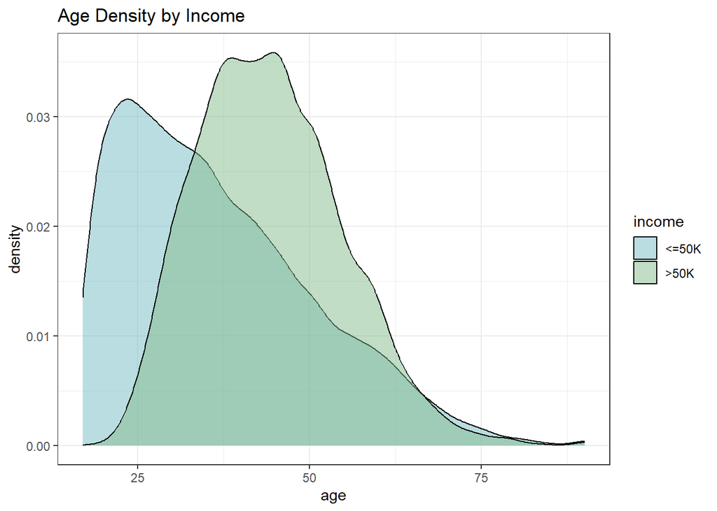

```r
df %>%
  ggplot(aes(x=age,fill=income)) +
  geom_density(alpha=0.5)+
  scale_fill_manual(values=c("#76BBC3","#84BC8E")) +
  theme_bw()+
  ggtitle("Age Density by Income")
```

### Factor variables by Income

#### Occupation plays an important role especially considering executive categories

#### Sex is also an important factor as men tend to have a higher income than women

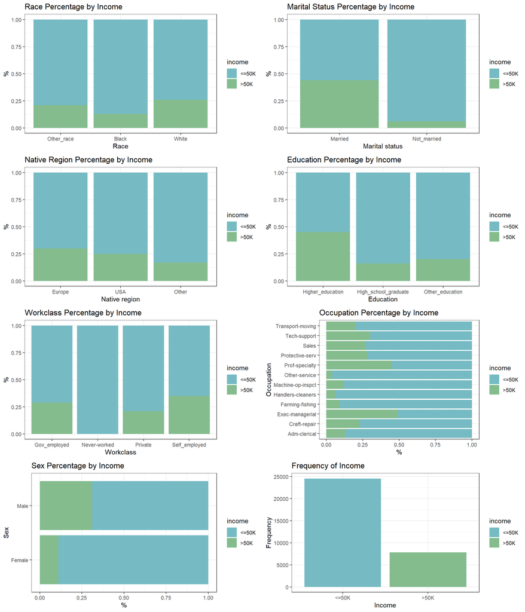

```r
grid.arrange(
  count(df,race,income) %>%
  group_by(race) %>%
  mutate(percent = n/sum(n)) %>%
  mutate(percent = round(percent,2)) %>%
  ggplot(aes(x=race,y=percent,fill=income)) +
  geom_bar(stat="identity") +
  scale_fill_manual(values=c("#76BBC3","#84BC8E")) +
  theme_bw()+
  xlab("Race")+
  ylab("%")+
  ggtitle("Race Percentage by Income")+
  theme_bw(),

  count(df,marital.status,income) %>%
  group_by(marital.status) %>%
  mutate(percent = n/sum(n)) %>%
  mutate(percent = round(percent,2)) %>%
  ggplot(aes(x=marital.status,y=percent,fill=income)) +
  geom_bar(stat="identity") +
  scale_fill_manual(values=c("#76BBC3","#84BC8E")) +
  theme_bw()+
  xlab("Marital status")+
  ylab("%")+
  ggtitle("Marital Status Percentage by Income")+
  theme_bw(),

  count(df,Native_region,income) %>%
  group_by(Native_region) %>%
  mutate(percent = n/sum(n)) %>%
  mutate(percent = round(percent,2)) %>%
  ggplot(aes(x=Native_region,y=percent,fill=income)) +
  geom_bar(stat="identity")+
  scale_fill_manual(values=c("#76BBC3","#84BC8E")) +
  xlab("Native region")+
  ylab("%")+
  ggtitle("Native Region Percentage by Income") +
  theme_bw(),

  count(df,education,income) %>%
  group_by(education) %>%
  mutate(percent = n/sum(n)) %>%
  mutate(percent = round(percent,2)) %>%
  ggplot(aes(x=education,y=percent,fill=income)) +
  geom_bar(stat="identity")+
  scale_fill_manual(values=c("#76BBC3","#84BC8E")) +
  xlab("Education")+
  ylab("%")+
  ggtitle("Education Percentage by Income") +
  theme_bw(),

  count(df,workclass,income) %>%
  group_by(workclass) %>%
  mutate(percent = n/sum(n)) %>%
  mutate(percent = round(percent,2)) %>%
  ggplot(aes(x=workclass,y=percent,fill=income)) +
  geom_bar(stat="identity")+
  scale_fill_manual(values=c("#76BBC3","#84BC8E")) +
  xlab("Workclass")+
  ylab("%")+
  ggtitle("Workclass Percentage by Income")+
  theme_bw(),

  count(df,occupation,income) %>%
  group_by(occupation) %>%
  mutate(percent = n/sum(n)) %>%
  mutate(percent = round(percent,2)) %>%
  ggplot(aes(y=occupation,x=percent,fill=income)) +
  geom_bar(stat="identity")+
  scale_fill_manual(values=c("#76BBC3","#84BC8E")) +
  ylab("Occupation")+
  xlab("%")+
  ggtitle("Occupation Percentage by Income")+
  theme_bw(),

  count(df,sex,income) %>%
  group_by(sex) %>%
  mutate(percent = n/sum(n)) %>%
  mutate(percent = round(percent,2)) %>%
  ggplot(aes(y=sex,x=percent,fill=income)) +
  geom_bar(stat="identity")+
  scale_fill_manual(values=c("#76BBC3","#84BC8E")) +
  ylab("Sex")+
  xlab("%")+
  ggtitle("Sex Percentage by Income") +
  theme_bw(),

  count(df,income) %>%
  ggplot(aes(x=income,y=n,fill=income)) +
  geom_bar(stat="identity")+
  scale_fill_manual(values=c("#76BBC3","#84BC8E")) +
  xlab("Income")+
  ylab("Frequency")+
  ggtitle("Frequency of Income") +
  theme_bw(),


  ncol = 2,nrow=4
)
```

### Variable’s dependency based on the Chi-squared test and the Cramer V score

```r
df_chi <- data.frame()
for (i in c("workclass","education","marital.status","occupation","race","sex","Native_region")){
  chi_test = chisq.test(df[[i]],df$income)
  chi_stat = chi_test$statistic
  cramer = cramerV(df[[i]],df$income)
  variable_name = i
  output = c(chi_stat,cramer,variable_name)
  df_chi = rbind(df_chi,output)
}

colnames(df_chi) <- c("chisq_stat","cramer's v","var_name")

df_chi <- df_chi %>%
  select(3,1,2) %>%
  mutate(chisq_stat = as.numeric(chisq_stat),
         `cramer's v` = as.numeric(`cramer's v`)) %>%
  mutate(chisq_stat = round(chisq_stat,2),
         `cramer's v` = round(`cramer's v`,2)) %>%
  arrange(desc(`cramer's v`))

df_chi %>%
  kable(align = "c") %>%
  kable_styling(position="center")
```

| var_name | chisq_stat | cramer’s v |
| --- | --- | --- |
| marital.status | 6118.30 | 0.43 |
| occupation | 4144.15 | 0.36 |
| education | 2178.03 | 0.26 |
| sex | 1481.62 | 0.21 |
| workclass | 448.26 | 0.12 |
| race | 274.12 | 0.09 |
| Native_region | 86.88 | 0.05 |

```r
table(df$income)
```

```
##
## <=50K  >50K
## 24550  7839
```

## Modelling

### Creating data partition

```r
data_partition <- caret::createDataPartition(df$income,times=1,p=0.75,list=FALSE)

train_set <- df[data_partition,]
test_set <- df[-data_partition,]

print(glue("train_set ncol: {ncol(train_set)}"))
```

```
## train_set ncol: 10
```

```r
print(glue("train_set nrow: {nrow(train_set)}"))
```

```
## train_set nrow: 24293
```

```r
print(glue("test_set ncol: {ncol(test_set)}"))
```

```
## test_set ncol: 10
```

```r
print(glue("test_set nrow: {nrow(test_set)}"))
```

```
## test_set nrow: 8096
```

```r
22498/(22498+7498)
```

```
## [1] 0.7500333
```

```r
table(train_set$income)
```

```
##
## <=50K  >50K
## 18413  5880
```

### Upsampling the train set

```r
train_set_upsampled <- caret::upSample(x=train_set[,1:9],y=train_set$income)
```

```r
table(train_set_upsampled$Class)
```

```
##
## <=50K  >50K
## 18413 18413
```

```r
head(train_set_upsampled)
```

```
##   age    workclass            education marital.status        occupation  race
## 1  90 Gov_employed High_school_graduate    Not_married      Adm-clerical White
## 2  66 Gov_employed      Other_education    Not_married      Adm-clerical Black
## 3  54      Private      Other_education    Not_married Machine-op-inspct White
## 4  41      Private      Other_education    Not_married    Prof-specialty White
## 5  34      Private High_school_graduate    Not_married     Other-service White
## 6  68 Gov_employed High_school_graduate    Not_married    Prof-specialty White
##      sex hours.per.week Native_region Class
## 1 Female             40           USA <=50K
## 2 Female             40           USA <=50K
## 3 Female             40           USA <=50K
## 4 Female             40           USA <=50K
## 5 Female             45           USA <=50K
## 6 Female             40           USA <=50K
```

```r
class(test_set[,10])
```

```
## [1] "factor"
```

```r
class(train_set_upsampled[,10])
```

```
## [1] "factor"
```

```r
lab_train <- as.factor(train_set_upsampled[, 10])
lab_test <- as.factor(test_set[[10]])
```

### Creating dummy variables

```r
dummy_train <- dummyVars("~ .", data = train_set_upsampled[,-10])
new_data_train <- data.frame(predict(dummy_train,newdata = train_set_upsampled[,-10]))
```

```r
train_set_upsampled <- cbind(new_data_train,lab_train)
```

```r
dummy_test <- dummyVars("~ .", data = test_set[,-10])
new_data_test <- data.frame(predict(dummy_test,newdata = test_set[,-10]))
```

```r
test_set <- cbind(new_data_test,lab_test)
```

```r
colnames(train_set_upsampled)[32]
```

```
## [1] "lab_train"
```

```r
colnames(test_set)[32]
```

```
## [1] "lab_test"
```

```r
colnames(train_set_upsampled)[32] <- "Income"
colnames(test_set)[32] <- "Income"
```

### XGBoost algorithm

#### How the algorithm works:

1. At the beginning, it assignes a “default” probability to each row in the data set. In case of binary classification, the algorithm would likely assign 0.5 probability to each row.
2. Decision tree is created. Usually the total amount of trees ranges from 500 to 2000 (1 per iteration), but it’s customizable. Each decision tree is build based on the residuals from the previous prediction. So at the beginning we would get only 0.5 and -0.5 residuals.
3. The algorithm would calculate similarity weights for each root and leaf node and then calculate gains. The decision trees might look like this:

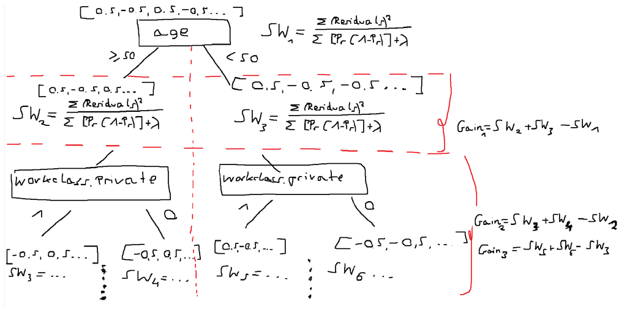

```r
ggplot() +
    background_image(readPNG("images/trees.png"))
```

```r
# Doing XGBoost for classification purposes.
grid_tune <- expand.grid(
  nrounds = 1500, #number of trees
  max_depth = 10,
  eta = 0.1, #c(0.025,0.05,0.1,0.3), #Learning rate
  gamma = 0.05, # pruning --> Should be tuned. i.e c(0, 0.05, 0.1, 0.5, 0.7, 0.9, 1.0)
  colsample_bytree = 0.5, # c(0.4, 0.6, 0.8, 1.0) subsample ratio of columns for tree
  min_child_weight = 1, # c(1,2,3) # the larger, the more conservative the model
  #is; can be used as a stop
  subsample = 0.75 # c(0.5, 0.75, 1.0) # used to prevent overfitting by sampling X% training
)
```

```r
class(train_set_upsampled[,32])
```

```
## [1] "factor"
```

```r
set.seed(123)
train_control <- trainControl(method = "cv",
                              number=3,
                              verboseIter = TRUE,
                              allowParallel = TRUE)
xgb_tune <- train(x = train_set_upsampled[,-32],
                  y = train_set_upsampled[,32],
                  trControl = train_control,
                  tuneGrid = grid_tune,
                  method= "xgbTree",
                  verbose = TRUE)
```

### Selecting model with the best hyperparameters

```r
xgb_tune$bestTune
```

```
##   nrounds max_depth eta gamma colsample_bytree min_child_weight subsample
## 1    1500        10 0.1  0.05              0.5                1      0.75
```

```r
train_control <- trainControl(method = "cv",
                              number=3,
                              verboseIter = TRUE,
                              allowParallel = TRUE)
final_grid <- expand.grid(nrounds = xgb_tune$bestTune$nrounds,
                           eta = xgb_tune$bestTune$eta,
                           max_depth = xgb_tune$bestTune$max_depth,
                           gamma = xgb_tune$bestTune$gamma,
                           colsample_bytree = xgb_tune$bestTune$colsample_bytree,
                           min_child_weight = xgb_tune$bestTune$min_child_weight,
                           subsample = xgb_tune$bestTune$subsample)
xgb_model <- train(x = train_set_upsampled[,-32],
                   y = train_set_upsampled[,32],
                   trControl = train_control,
                   tuneGrid = final_grid,
                   method = "xgbTree",
                   verbose = TRUE)
```

### Fitting the model on the test set

```r
head(predict(xgb_model, test_set))
```

```
## [1] <=50K <=50K <=50K >50K  <=50K <=50K
## Levels: <=50K >50K
```

```r
xgb.pred <- predict(xgb_model, test_set)
```

### Confusion matrix

```r
# Confusion Matrix
confusionMatrix(as.factor(xgb.pred),
                as.factor(test_set$Income))
```

```
## Confusion Matrix and Statistics
##
##           Reference
## Prediction <=50K >50K
##      <=50K  5138  665
##      >50K    999 1294
##
##                Accuracy : 0.7945
##                  95% CI : (0.7855, 0.8032)
##     No Information Rate : 0.758
##     P-Value [Acc > NIR] : 3.587e-15
##
##                   Kappa : 0.4705
##
##  Mcnemar's Test P-Value : 3.259e-16
##
##             Sensitivity : 0.8372
##             Specificity : 0.6605
##          Pos Pred Value : 0.8854
##          Neg Pred Value : 0.5643
##              Prevalence : 0.7580
##          Detection Rate : 0.6346
##    Detection Prevalence : 0.7168
##       Balanced Accuracy : 0.7489
##
##        'Positive' Class : <=50K
##
```

1. Accuracy Score: Proportion of correctly classified observations
2. No Information Rate: If we were to guess the most frequent class, what accuracy would we get?
3. Kappa: a metric that considers both the true positive rate and the false positive rate, providing a more balanced assessment of the model’s performance. Kappa ranges from -1 to 1, with 0 indicating no better than random chance, and 1 indicating perfect agreement between predictions and true values. (https://changjunlee.com/blogs/posts/4_confusion_mat_and_roc)
4. Sensitivity: Proportion of correctly classified positive observations
5. Specificity: Proportion of correctly classified negative observations
6. Pos Pred Value (precision): Out of all of the observations that the model classified as positive, how many of them were actually positive?
7. Neg Pred Value: Out of all of the observations that the model classified as negative, how many of them were actually negative?
8. Prevalence: Proportion of actually positive observations in the data set